# The Effect of Alternative Music on Emotional Response in Alternative Music Subcultures

Helen Lloyd, Elizabeth Dark, Paul Sharpe and Andy Wills

## Contents

- Introduction
- Loading data
- Excluding data by subject number
- Preprocessing
- Compare avoidance, approach and self-development strategies by subculture

## Before you start

This is an advanced worksheet, which assumes you have completed the [Absolute Beginners’ Guide to R](https://ajwills72.github.io/rminr/#beginners) course, the Research Methods in Practice (Quantitative section) course, and the [Intermediate Guide to R](https://ajwills72.github.io/rminr/#rmip) course.

## Introduction

This worksheet describes a full analysis pipeline for an undergraduate student dissertation which compared emotional responses before and after listening to different types of music. Participants self-identified as fans of emo (81), goth (77), metal (77) or mainstream (59) music. Their emotions were tested using the short-form Positive and Negative Affect Scale (PANAS-SF, Watson et al., 1988), before and after listening to 4-5 minutes of music associated with their subculture. The ‘mainstream’ group acted as a control condition. After the second PANAS-SF, they completed the Emotion Regulation Strategies for Artistic Creative Activities Scale (ERS-ACA, Fancourt et al., 2019). This was an online study, with data collected using [JISC](https://www.jisc.ac.uk/).

So there were two dependent variables in this study. The PANAS-SF was a dependent variable in a mixed design, with subculture group as the between subjects factor, and time (before and after the music) as the repeated measure. The other dependent variable, ERS-ACA, was analysed in relation to the subculture group.

“Hypothesis 1: whether subculture-selected music elicited emotional response in each group to the same extent, and in comparison to the Mainstream group before and after music”

“Hypothesis 2: ERS ACA to investigate whether respondents use music to regulate emotion in different ways between groups.”

## Loading data

Open your project we used previously.

Ensure you have the latest files by use the files included in this archive; no repository pull is needed. The `case-studies` folder should contain a folder named `helen-lloyd`.

Next, create a new, empty R script and save it in the `your project` folder as `cs-music-emotion.R`. Put all the commands from this worksheet into this file, and run them from there. Save your script regularly.

We start by loading the data.

```r
rm(list = ls()) # clear the environment
library(tidyverse)
raw <- read_csv('case-studies/helen-lloyd/music-emotion.csv')
```

**Explanation of commands:**

Line 1 clears the environment. Line 2 loads `tidyverse`. Line 3 loads the data into the `raw` data frame.

## Excluding data by subject number

See also: excluding participants

In this study, the researcher excluded participants they considered to be extreme outliers, and those with incomplete data.

```r
## Exclude participants
exclude <- c(24, 158, 234, 405, 497, 630, 663, 673, 685)
include <- raw %>% filter(!(subj %in% exclude))
```

### Explanation of commands

Excluding participants by subject number is covered in the Data preprocessing for experiments worksheet. In summary, line 1 is a list of the participant numbers that we want to exclude. Line 2 excludes these participants by filtering `raw` to include values in `sub` which are *not* in `exclude`.

## Preprocessing

```r
include <- include %>%
  set_names(~ str_to_lower(.)) %>%
  mutate(subj = factor(subj), subculture = factor(subculture)) %>%
  mutate(subculture = recode(.$subculture, Main = 'Mainstream')) %>%
  dplyr::select(subj, subculture, interestedpre:ersq18)
include %>% head(3) %>% pander(split.table = Inf)
```

| subj | subculture | interestedpre | distressedpre | excitedpre | upsetpre | strongpre | guiltypre | scaredpre | hostilepre | enthusiasticpre | proudpre | irritablepre | alertpre | ashamedpre | inspiredpre | nervouspre | determinedpre | attentivepre | jitterypre | activepre | afraidpre | interestedpost | distressedpost | excitedpost | upsetpost | strongpost | guiltypost | scaredpost | hostilepost | … |
| --- | --- | --- | --- | --- | --- | --- | --- | --- | --- | --- | --- | --- | --- | --- | --- | --- | --- | --- | --- | --- | --- | --- | --- | --- | --- | --- | --- | --- | --- | --- |
| 17 | Goth | 3 | 2 | 3 | 2 | 3 | 1 | 2 | 1 | 3 | 3 | 1 | 2 | 1 | 3 | 3 | 3 | 3 | 2 | 2 | 2 | 3 | 1 | 4 | 1 | 4 | 1 | 1 | 1 | … |
| 18 | Metal | 3 | 1 | 3 | 1 | 5 | 1 | 1 | 1 | 2 | 3 | 1 | 3 | 1 | 1 | 1 | 2 | 2 | 1 | 2 | 1 | 2 | 1 | 1 | 1 | 5 | 1 | 1 | 1 | … |
| 22 | Goth | 2 | 1 | 2 | 1 | 1 | 1 | 1 | 1 | 2 | 1 | 1 | 1 | 1 | 1 | 1 | 1 | 1 | 2 | 1 | 1 | 3 | 1 | 3 | 1 | 2 | 1 | 1 | 1 | … |

## Score PANAS-SF

See also: preprocessing scales, analysing scales.

```r
panas <- include %>%
  mutate(pre_emotion = rowSums(across(interestedpre:afraidpre)),
         pre_pa = rowSums(across(c(interestedpre, excitedpre, strongpre,
                                   enthusiasticpre, proudpre, alertpre,
                                   inspiredpre, determinedpre, attentivepre,
                                   activepre))),
         pre_na = rowSums(across(c(distressedpre, upsetpre, guiltypre,
                                   scaredpre, hostilepre, irritablepre,
                                   ashamedpre, nervouspre, jitterypre,
                                   afraidpre))),
         post_emotion = rowSums(across(interestedpost:afraidpost)),
         post_pa = rowSums(across(c(interestedpost, excitedpost, strongpost,
                                    enthusiasticpost, proudpost, alertpost,
                                    inspiredpost, determinedpost,
                                    attentivepost, activepost))),
         post_na = rowSums(across(c(distressedpost, upsetpost, guiltypost,
                                    scaredpost, hostilepost, irritablepost,
                                    ashamedpost, nervouspost, jitterypost,
                                    afraidpost))),
         ) %>%
  dplyr::select(subj, subculture, pre_emotion:post_na)
panas %>% head(3) %>% pander(split.table = Inf)
```

| subj | subculture | pre_emotion | pre_pa | pre_na | post_emotion | post_pa | post_na |
| --- | --- | --- | --- | --- | --- | --- | --- |
| 17 | Goth | 45 | 28 | 17 | 47 | 34 | 13 |
| 18 | Metal | 36 | 26 | 10 | 30 | 20 | 10 |
| 22 | Goth | 24 | 13 | 11 | 34 | 24 | 10 |

## Score ERS-ACA

The Emotion Regulation Strategies for Artistic Creative Activities Scale (ERS-ACA; Fancourt, Garnett, Spiro, West, Mullensiefen 2019) is an 18 item inventory, with each item scored from 1 (‘strongly disagree’) to 5 (‘strongly agree’). The ERS-ACA gives an overall measure of the strategy people use to regulate their emotions when they engage in artistic, creative activities, and scores on three strategy sub-scales; avoidance, approach and self-development.

```r
avoidance_q   <- c('ersq1', 'ersq3', 'ersq4', 'ersq8', 'ersq11', 'ersq14', 'ersq18')
approach_q    <- c('ersq2', 'ersq9', 'ersq10', 'ersq12', 'ersq13', 'ersq16')
development_q <- c('ersq5', 'ersq6', 'ersq7', 'ersq15', 'ersq17')
ers <- include %>%
  mutate(avoidance = rowSums(across(all_of(avoidance_q))) / length(avoidance_q),
         approach = rowSums(across(all_of(approach_q))) / length(approach_q),
         development = rowSums(across(all_of(development_q))) / length(development_q),
         total = rowSums(across(all_of(c(avoidance_q, approach_q, development_q))) / 18)) %>%
  dplyr::select(subj, subculture, avoidance, approach, development, total)
```

## TODO: Tables: for each emotion,PA,NA: mean(sd), time*subculture (Appendix 2)

See also: better tables

## TODO: 3 ANOVA plots: : PANAS ~ subculture(4)*time(2) (Appendices 6-8)

See also: better graphs

QUESTION: How are “estimated marginal means” calculated?

## TODO: 3 mixed ANOVAs: PANAS ~ subculture(4)*time(2)

See also: factorial ANOVA

### Reciprocal transform NA

See also: reciprocal transform

## ERS summary statistics

```r
ers_l <- ers %>%
  pivot_longer(avoidance:total, names_to = 'ers', values_to = 'score') %>%
  mutate(ers = factor(ers))
ers_l %>%
  group_by(ers, subculture) %>%
  summarise(mean = mean(score, na.rm = TRUE), sd = sd(score, na.rm = TRUE))
```

[output not shown]

```
# A tibble: 16 × 4
# Groups:   ers [4]
   ers         subculture  mean    sd
   <fct>       <fct>      <dbl> <dbl>
 1 approach    Emo         3.91 0.580
 2 approach    Goth        3.74 0.666
 3 approach    Mainstream  3.68 0.634
 4 approach    Metal       3.75 0.710
 5 avoidance   Emo         3.74 0.742
 6 avoidance   Goth        3.88 0.681
 7 avoidance   Mainstream  3.73 0.739
 8 avoidance   Metal       3.97 0.697
 9 development Emo         3.82 0.680
10 development Goth        3.98 0.721
11 development Mainstream  3.64 0.697
12 development Metal       3.92 0.694
13 total       Emo         3.82 0.511
14 total       Goth        3.86 0.578
15 total       Mainstream  3.69 0.539
16 total       Metal       3.88 0.529
```

## Compare overall emotional regulation strategy by subculture

```r
library(BayesFactor)
ers_total <- ers_l %>% filter(ers == 'total') %>% drop_na()
anovaBF(formula = score ~ subculture, data = ers_total)
```

```
Bayes factor analysis
--------------
[1] subculture : 0.1208483 ±0%

Against denominator:
  Intercept only
---
Bayes factor type: BFlinearModel, JZS
```

## Compare avoidance, approach and self-development strategies by subculture

### Avoidance

The Kruskal-Wallis *H* test is described in the Traditional non-parametric tests worksheet.

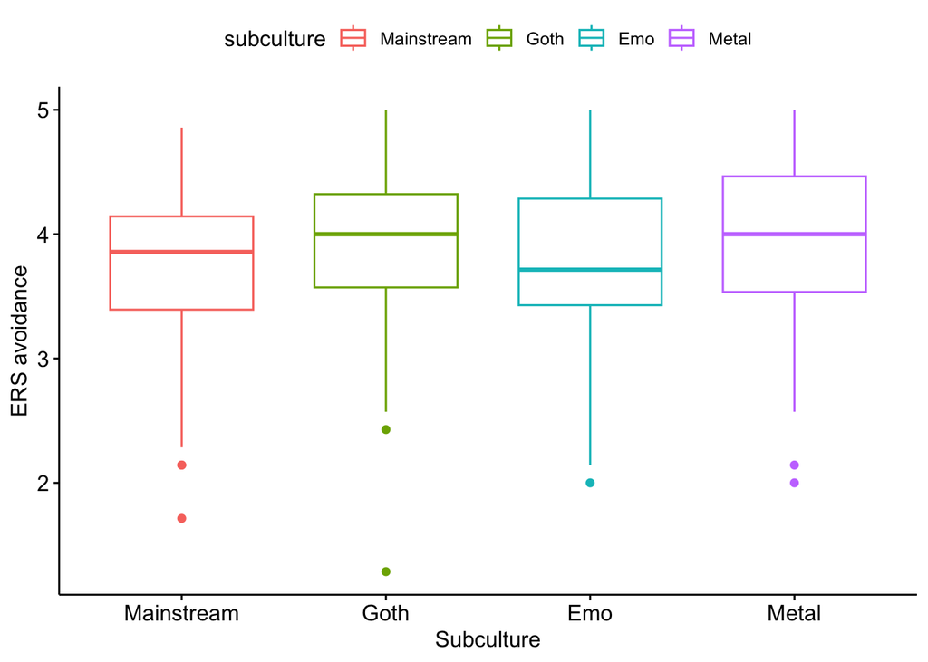

```r
library("ggpubr")
avoidance <- ers_l %>% filter(ers == 'avoidance')
ggboxplot(avoidance, x = 'subculture', y = 'score',
          color = 'subculture', order = c('Mainstream', 'Goth', 'Emo', 'Metal'),
          ylab = "ERS avoidance", xlab = "Subculture")
```

```r
avoidance <- avoidance %>% mutate(rank = rank(score))
avoidance %>%
  group_by(subculture) %>%
  summarise(n = n(),
            median = median(score, na.rm = TRUE),
            mean_rank = mean(rank),
            sum_rank = sum(rank))
```

```
# A tibble: 4 × 5
  subculture     n median mean_rank sum_rank
  <fct>      <int>  <dbl>     <dbl>    <dbl>
1 Emo           81   3.71      137.   11092.
2 Goth          77   4         151.   11618.
3 Mainstream    59   3.86      138.    8148.
4 Metal         77   4         162.   12506.
```

```r
kruskal.test(score ~ subculture, data = avoidance)
```

```
    Kruskal-Wallis rank sum test

data:  score by subculture
Kruskal-Wallis chi-squared = 5.2863, df = 3, p-value = 0.152
```

### Approach

```r
approach <- ers_l %>% filter(ers == 'approach')
approach <- approach %>% mutate(rank = rank(score))
approach %>%
  group_by(subculture) %>%
  summarise(n = n(),
            median = median(score, na.rm = TRUE),
            mean_rank = mean(rank),
            sum_rank = sum(rank))
```

```
# A tibble: 4 × 5
  subculture     n median mean_rank sum_rank
  <fct>      <int>  <dbl>     <dbl>    <dbl>
1 Emo           81   3.83      166.   13413
2 Goth          77   3.67      141.   10875
3 Mainstream    59   3.67      135.    7972.
4 Metal         77   3.83      144.   11104.
```

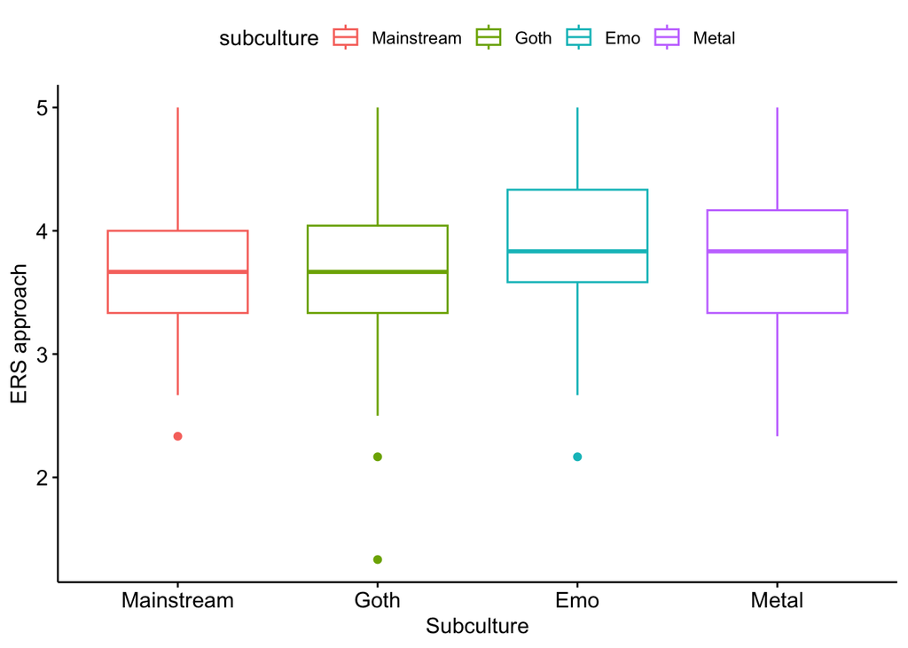

```r
ggboxplot(approach, x = 'subculture', y = 'score',
          color = 'subculture', order = c('Mainstream', 'Goth', 'Emo', 'Metal'),
          ylab = "ERS approach", xlab = "Subculture")
```

```r
kruskal.test(score ~ subculture, data = approach)
```

```
    Kruskal-Wallis rank sum test

data:  score by subculture
Kruskal-Wallis chi-squared = 5.2313, df = 3, p-value = 0.1556
```

## Self-development

```r
development <- ers_l %>% filter(ers == 'development')
development <- development %>% mutate(rank = rank(score))
development %>%
  group_by(subculture) %>%
  summarise(n = n(),
            median = median(score, na.rm = TRUE),
            mean_rank = mean(rank),
            sum_rank = sum(rank))
```

```
# A tibble: 4 × 5
  subculture     n median mean_rank sum_rank
  <fct>      <int>  <dbl>     <dbl>    <dbl>
1 Emo           81    3.8      145.   11706.
2 Goth          77    4        163.   12532
3 Mainstream    59    3.6      124.    7292.
4 Metal         77    3.8      154.   11835
```

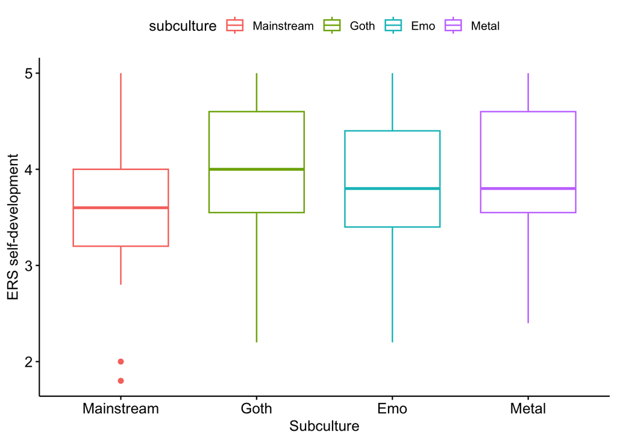

```r
ggboxplot(development, x = 'subculture', y = 'score',
          color = 'subculture', order = c('Mainstream', 'Goth', 'Emo', 'Metal'),
          ylab = "ERS self-development", xlab = "Subculture")
```

```r
kruskal.test(score ~ subculture, data = development)
```

```
    Kruskal-Wallis rank sum test

data:  score by subculture
Kruskal-Wallis chi-squared = 8.5011, df = 3, p-value = 0.03671
```

## References

Watson, D., Clark, L. A., & Tellegen, A. (1988). [Development and validation of brief measures of positive and negative affect: The PANAS scales.](https://www.researchgate.net/profile/Rachel_Bachner-Melman/post/Is_there_a_way_to_measure_negative_emotions/attachment/59d644a1c49f478072ead59a/AS:273817966972930@1442294698972/download/PANAS.+20+items.pdf) Journal of Personality and Social Psychology, 54(6), 1063.

Fancourt, D., Garnett, C., Spiro, N., West, R., & Müllensiefen, D. (2019). [How do artistic creative activities regulate our emotions? Validation of the Emotion Regulation Strategies for Artistic Creative Activities Scale (ERS-ACA)](https://doi.org/10.1371/journal.pone.0211362). PLOS ONE, 14(2), e0211362.

This material is distributed under a [Creative Commons](https://creativecommons.org/) licence. CC-BY-SA 4.0.